# M4_W1_L2_Plotting

## Base graphics

Base graphics are used most commonly and are a very powerful system for creating 2-D graphics.

There are two phases to creating a base plot:

- Initialising a new plot
- Annotating (adding to) an existing plot

Calling **plot(x, y)** or **hist(x)** will launch a graphics device (if one is not already open) and draw a new plot on the device.

If the arguments to **plot** are not of some special class, then the *default* method for **plot** is called; this function has *many* arguments, letting you set the title, x axis label, y axis label, etc.

The base graphics system has *many* parameters that can be set and tweaked; these parameters are documented in **?par**; it wouldn’t hurt to try to memorise this help page!

## Simple base graphics

### Histogram

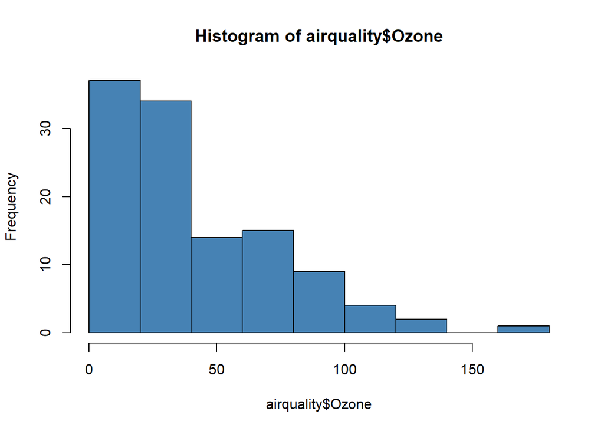

```r
library(datasets)
hist(airquality$Ozone, col = "steelblue") ## Draw a new plot
```

### Scatterplot

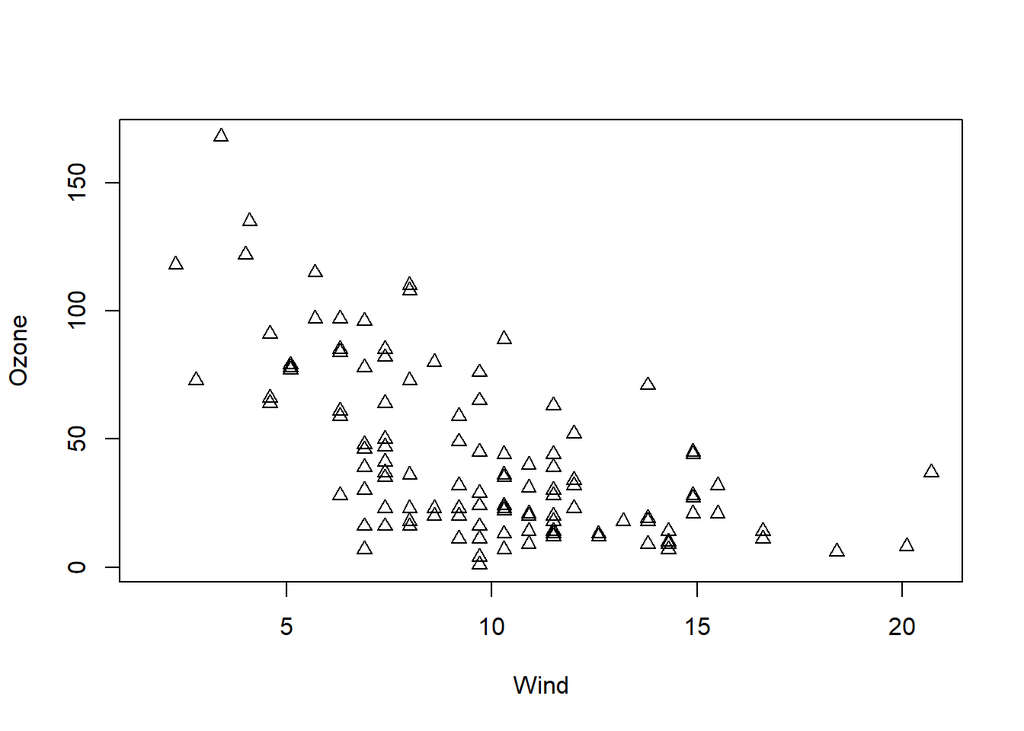

```r
library(datasets)
with(airquality, plot(Wind, Ozone, pch = 2))
```

### Boxplot

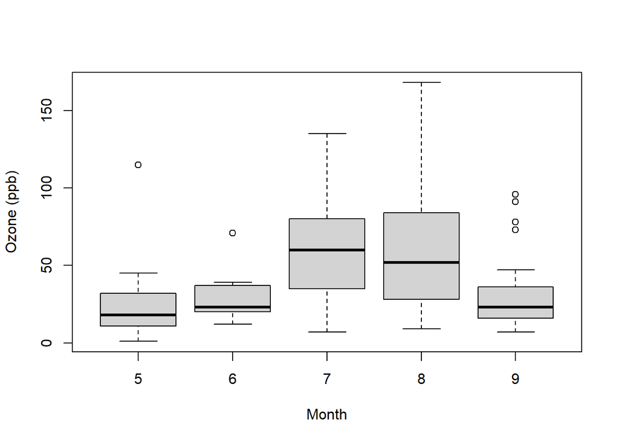

```r
library(datasets)
airquality <- transform(airquality, Month = factor(Month))
boxplot(Ozone ~ Month, airquality, xlab = "Month", ylab = "Ozone (ppb)")
```

## Some important base graphics parameters

Many base plotting functions share a set of parameters. Here are a few key ones:

- **pch**: the plotting symbol (default is open circle)
- **lty**: the line type (default is solid line), can be dashed, dotted, etc.
- **lwd**: the line width, specified as an integer multiple
- **col**: the plotting colour, specified as a number, string, or hex code; the **colors()** function gives you a vector of colors by name
- **xlab**: character string for the x-axis label
- **ylab**: character string for the y-axis label

The par() function is used to specify *global* graphics parameters that affect all plots in an R session. These parameters can be overridden when specified as arguments to specific plotting functions.

- **las**: the orientation of the axis labels on the plot
- **bg**: the background colour
- **mar**: the margin size
- **oma**: the outer margin size (default is 0 for all sides)
- **mfrow**: the number of plots per row, column (plots are filled row-wise)
- **mfcol**: number of plots per row, column (plots are filled column-wise)

Default values for global graphics paramaters

```r
par("lty")
```

```
## [1] "solid"
```

```r
par("col")
```

```
## [1] "black"
```

```r
par("pch")
```

```
## [1] 1
```

```r
par("bg")
```

```
## [1] "white"
```

```r
par("mar")
```

```
## [1] 5.1 4.1 4.1 2.1
```

```r
par("mfrow")
```

```
## [1] 1 1
```

# Base Plotting System (Part 2)

## Base plotting functions

- **plot**: make a scatterplot, or other type of plot depending on the class of the object being plotted
- **lines**: add lines to a plot, given a vector of x values and a corresponding vector of y values (or a 2-column matrix); this function just connects the dots
- **points**: add points to a plot
- **text**: add text labels to a plot using specified x, y coordinates
- **title**: add annotations to x, y axis labels, title, subtitle, outer margin
- **mtext**: add arbitrary text to the margins (inner or outer) of the plot
- **axis**: adding axis ticks/labels

## Base plot with annotation

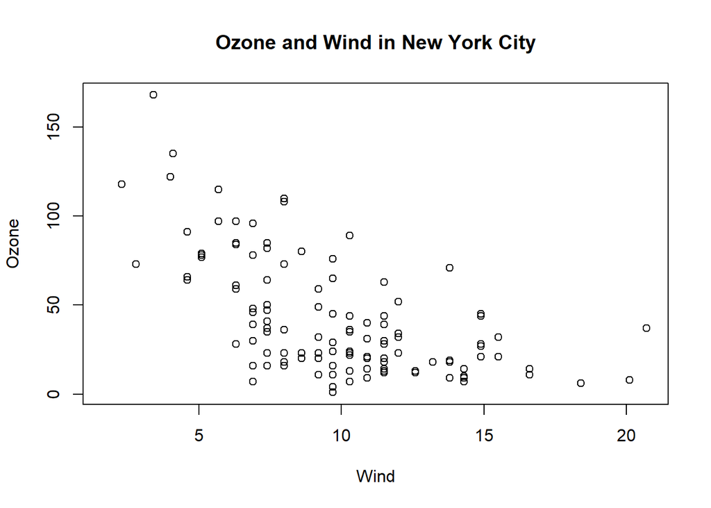

```r
library(datasets)
with(airquality, plot(Wind, Ozone))
title(main = "Ozone and Wind in New York City") ## Add a title
```

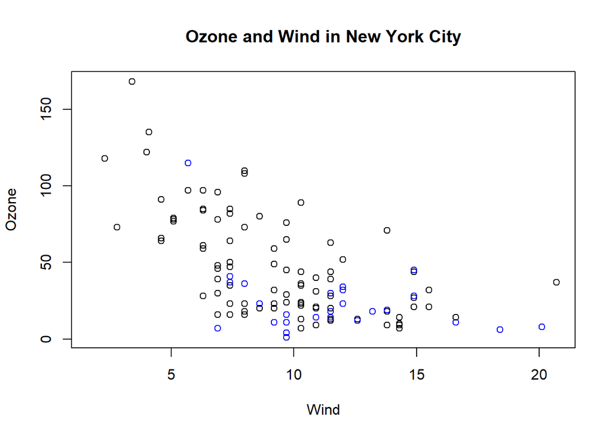

```r
with(airquality, plot(Wind, Ozone, main = "Ozone and Wind in New York City"))
with(subset(airquality, Month == 5), points(Wind, Ozone, col = "blue"))
```

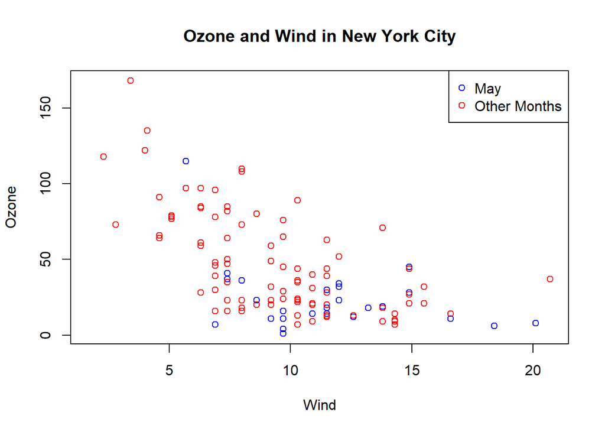

```r
with(airquality, plot(Wind, Ozone, main = "Ozone and Wind in New York City", type = "n")) ## type = "n" sets up the plot without any data
with(subset(airquality, Month == 5), points(Wind, Ozone, col = "blue"))
with(subset(airquality, Month != 5), points(Wind, Ozone, col = "red"))
legend("topright", pch = 1, col = c("blue", "red"), legend = c("May", "Other Months"))
```

## Base plot with regression line

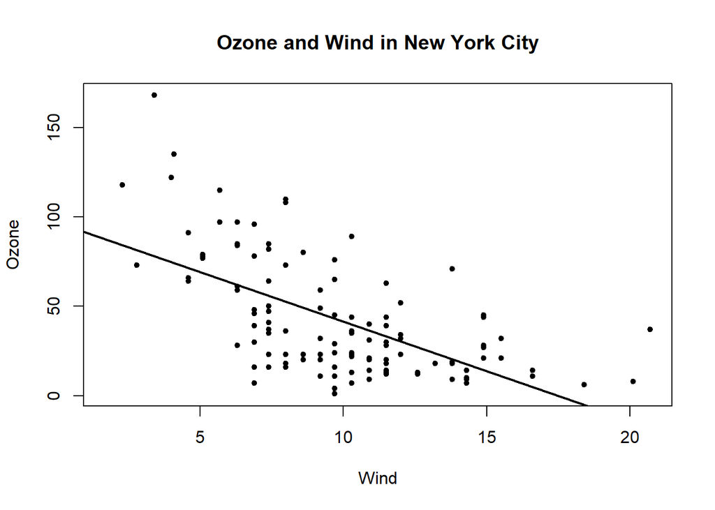

```r
with(airquality, plot(Wind, Ozone, main = "Ozone and Wind in New York City", pch = 20))
model <- lm(Ozone ~ Wind, airquality)
abline(model, lwd = 2)
```

## Multiple base plots

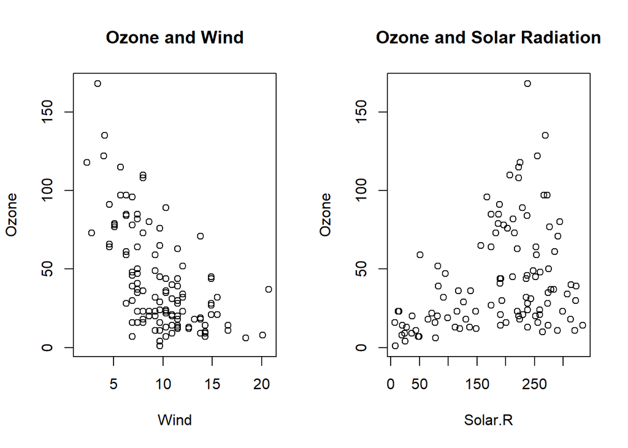

```r
par(mfrow = c(1, 2))
with(airquality, {
        plot(Wind, Ozone, main = "Ozone and Wind")
        plot(Solar.R, Ozone, main = "Ozone and Solar Radiation")
})
```

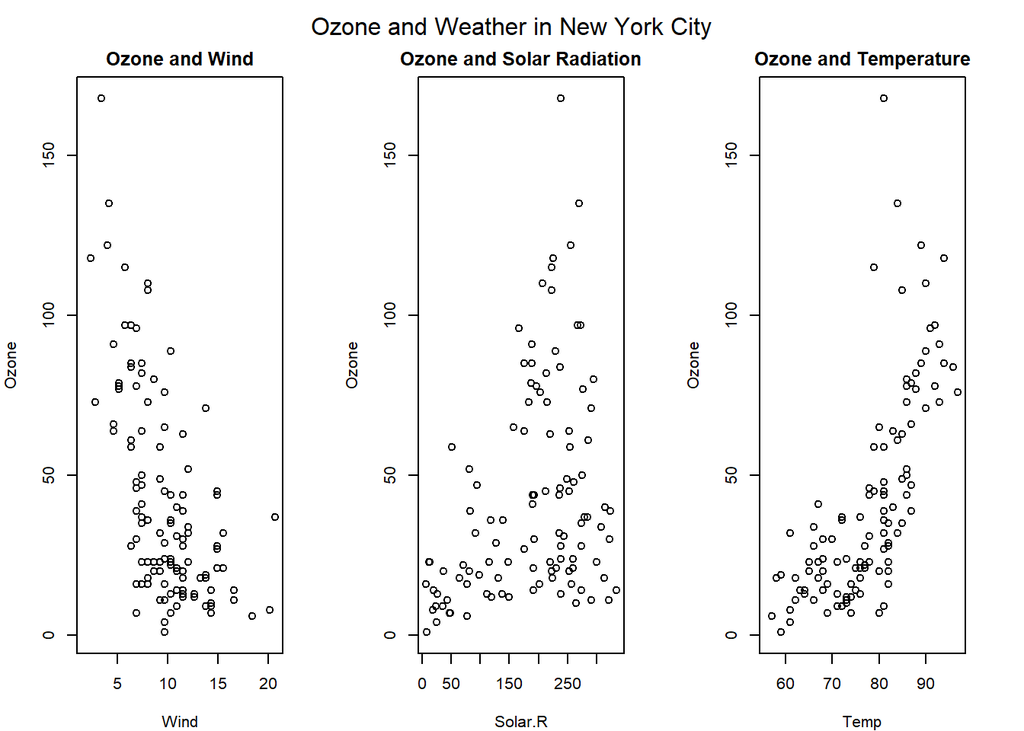

```r
par(mfrow = c(1, 3), mar = c(4, 4, 2, 3), oma = c(0, 0, 2, 0))
with(airquality, {
        plot(Wind, Ozone, main = "Ozone and Wind")
        plot(Solar.R, Ozone, main = "Ozone and Solar Radiation")
        plot(Temp, Ozone, main = "Ozone and Temperature")
        mtext("Ozone and Weather in New York City", outer = TRUE)
})
```

## Summary

Plots in the base plotting system are created by calling successive R functions to “build up” a plot

Plotting occurs in two stages:

- creation of a plot
- annotation of a plot

The base plotting system is very flexible and offers a high degree of control over plottiing.

# Base Plotting Demonstration

We are going to play with some synthetic data to try out the base plotting functionalities.

```r
x <- rnorm(100)
```

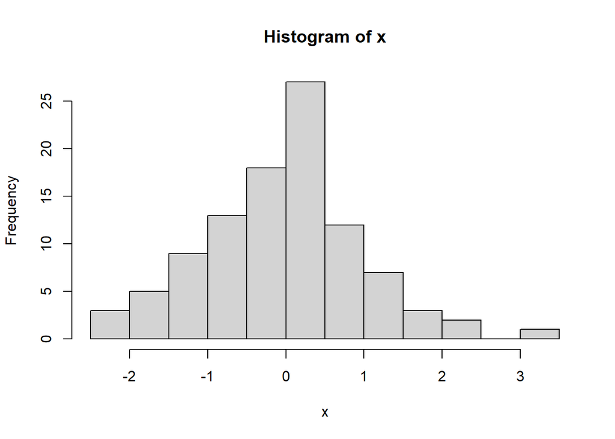

```r
hist(x)
```

We can see a number of defualt elements in the histogram … axis labels and a title.

```r
y <- rnorm(100)
```

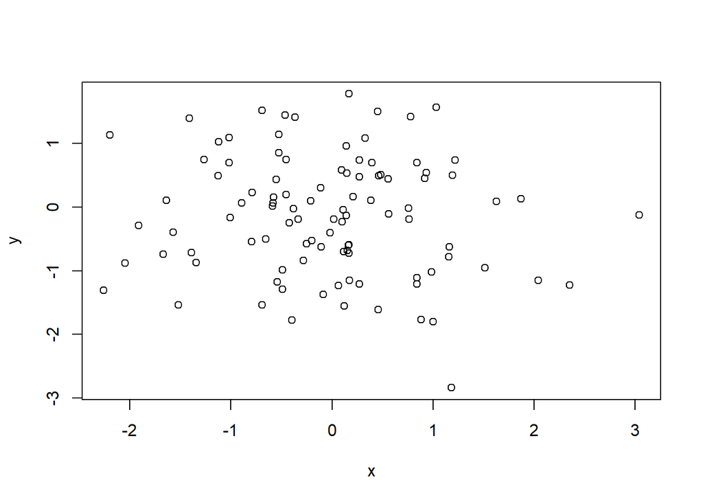

```r
plot(x, y)
```

In this example we can see the default axes labels and the default plotting symbot (the open circle).

If the above plot appeared in the plotting window we would also notice the default margins, i.e. 5 lines of text for the bottom margin, 4 lines of text for the left and top margin, and two lines of text for the right margin.

The margins can be adjusted using the mar function.

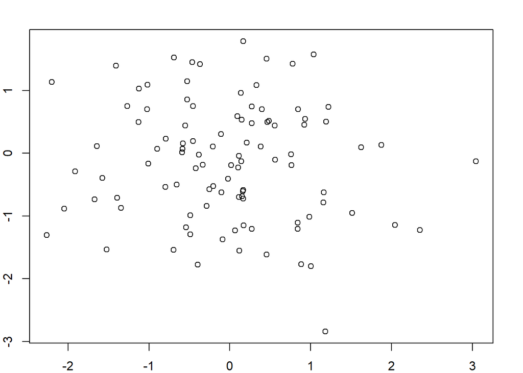

```r
par(mar = c(2, 2, 2, 2))
plot(x, y)
```

This has made the margins around the plot even, but it has also meant that there is no space available for the axes labels.

Here we change the plotting symbol.

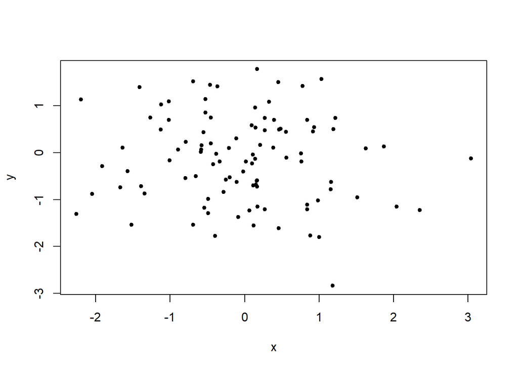

```r
plot(x, y, pch = 20)
```

There is a demo file that shows all of the points options

```r
example(points)
```

```
##
## points> require(stats) # for rnorm
##
## points> plot(-4:4, -4:4, type = "n")  # setting up coord. system
```

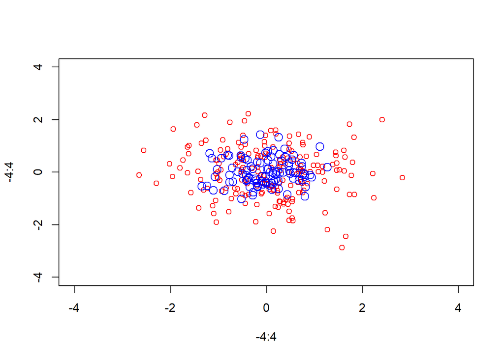

```
##
## points> points(rnorm(200), rnorm(200), col = "red")
##
## points> points(rnorm(100)/2, rnorm(100)/2, col = "blue", cex = 1.5)
##
## points> op <- par(bg = "light blue")
##
## points> x <- seq(0, 2*pi, length.out = 51)
##
## points> ## something "between type='b' and type='o'":
## points> plot(x, sin(x), type = "o", pch = 21, bg = par("bg"), col = "blue", cex = .6,
## points+  main = 'plot(..., type="o", pch=21, bg=par("bg"))')
```

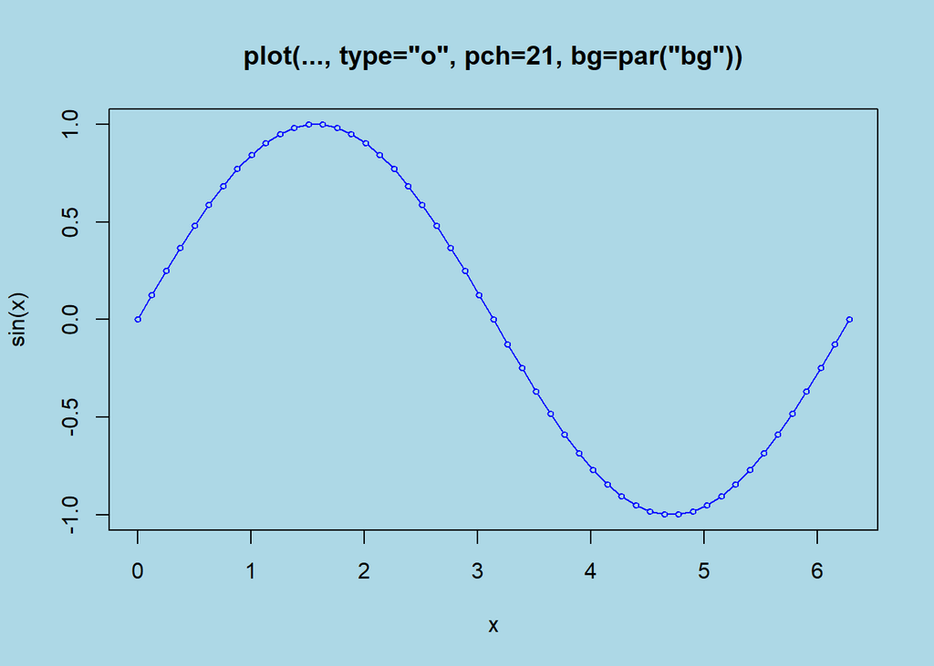

```
##
## points> par(op)
##
## points> ## Not run:
## points> ##D ## The figure was produced by calls like
## points> ##D png("pch.png", height = 0.7, width = 7, res = 100, units = "in")
## points> ##D par(mar = rep(0,4))
## points> ##D plot(c(-1, 26), 0:1, type = "n", axes = FALSE)
## points> ##D text(0:25, 0.6, 0:25, cex = 0.5)
## points> ##D points(0:25, rep(0.3, 26), pch = 0:25, bg = "grey")
## points> ## End(Not run)
## points>
## points> ##-------- Showing all the extra & some char graphics symbols ---------
## points> pchShow <-
## points+   function(extras = c("*",".", "o","O","0","+","-","|","%","#"),
## points+            cex = 3, ## good for both .Device=="postscript" and "x11"
## points+            col = "red3", bg = "gold", coltext = "brown", cextext = 1.2,
## points+            main = paste("plot symbols :  points (...  pch = *, cex =",
## points+                         cex,")"))
## points+   {
## points+     nex <- length(extras)
## points+     np  <- 26 + nex
## points+     ipch <- 0:(np-1)
## points+     k <- floor(sqrt(np))
## points+     dd <- c(-1,1)/2
## points+     rx <- dd + range(ix <- ipch %/% k)
## points+     ry <- dd + range(iy <- 3 + (k-1)- ipch %% k)
## points+     pch <- as.list(ipch) # list with integers & strings
## points+     if(nex > 0) pch[26+ 1:nex] <- as.list(extras)
## points+     plot(rx, ry, type = "n", axes  =  FALSE, xlab = "", ylab = "", main = main)
## points+     abline(v = ix, h = iy, col = "lightgray", lty = "dotted")
## points+     for(i in 1:np) {
## points+       pc <- pch[[i]]
## points+       ## 'col' symbols with a 'bg'-colored interior (where available) :
## points+       points(ix[i], iy[i], pch = pc, col = col, bg = bg, cex = cex)
## points+       if(cextext > 0)
## points+           text(ix[i] - 0.3, iy[i], pc, col = coltext, cex = cextext)
## points+     }
## points+   }
##
## points> pchShow()
```

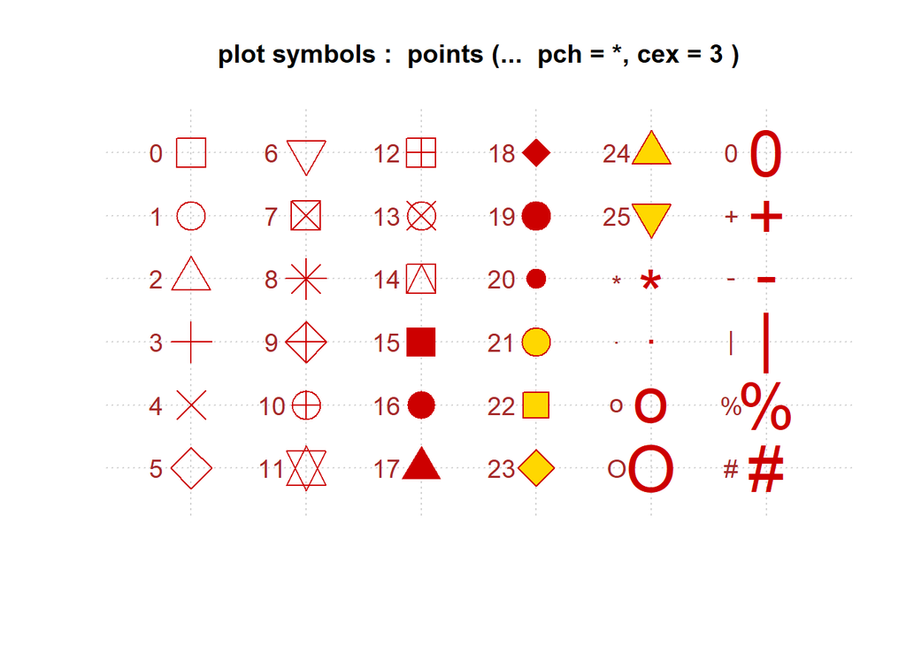

```
##
## points> pchShow(c("o","O","0"), cex = 2.5)
```

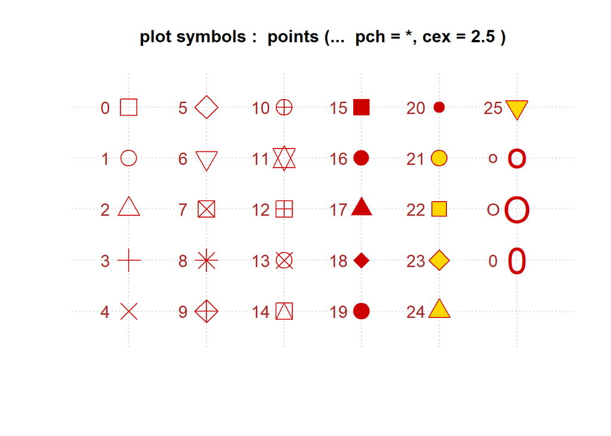

```
##
## points> pchShow(NULL, cex = 4, cextext = 0, main = NULL)
```

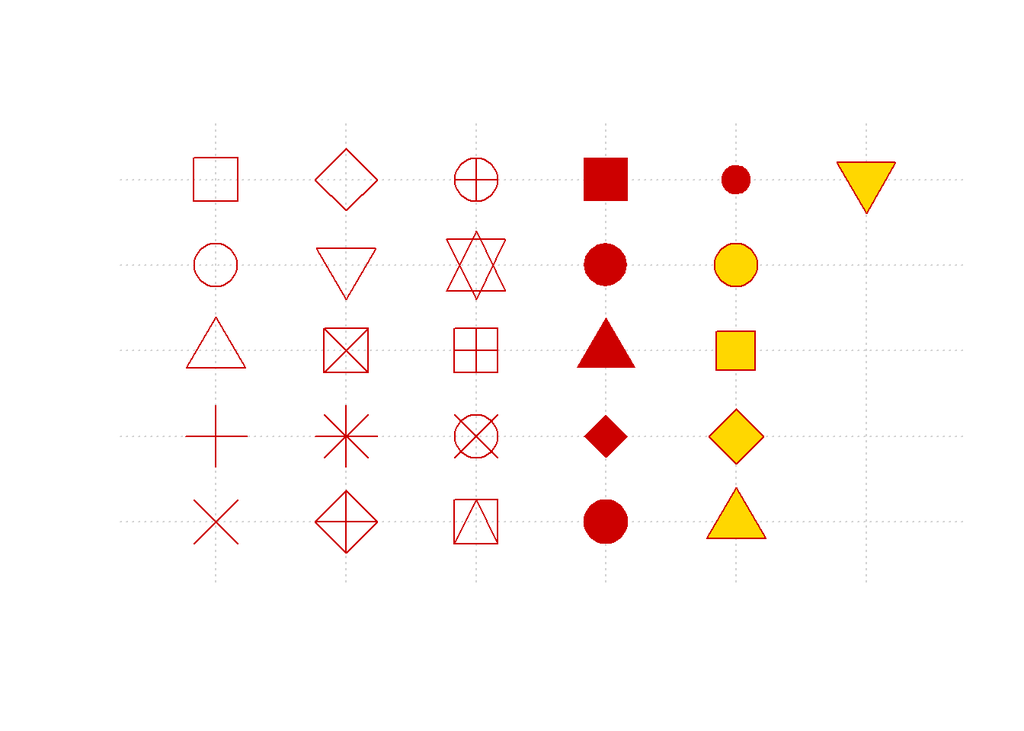

[output not shown]

we can add a title, text, a legend or a line to the plot.

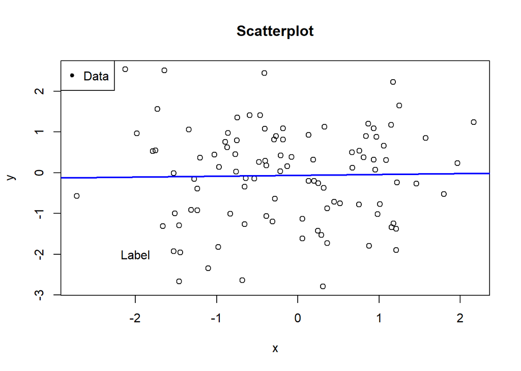

```r
x <- rnorm(100)
y <- rnorm(100)
plot(x, y)
title("Scatterplot")
text(-2, -2, "Label")
legend("topleft", legend = "Data", pch = 20)
fit <- lm(y ~ x)
abline(fit, lwd = 2, col = "blue")
```

## Multiple scatterplots

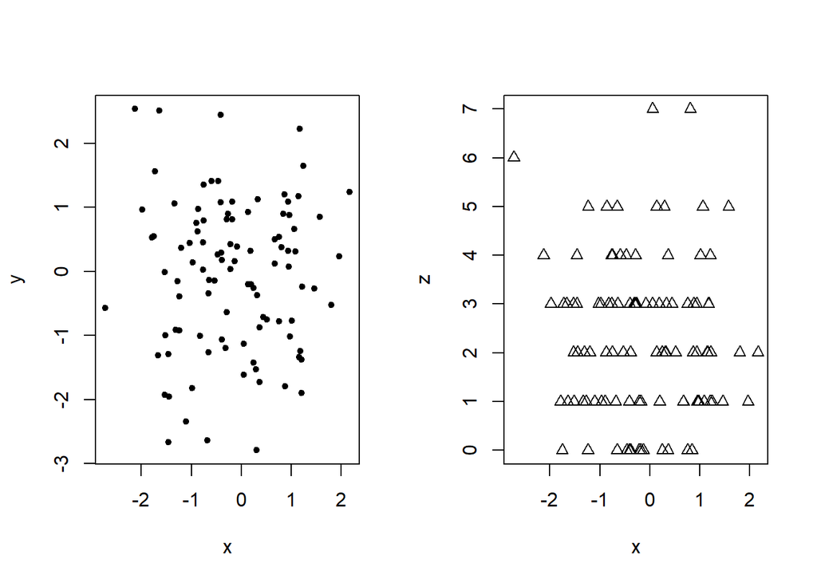

```r
z <- rpois(100, 2)
par(mfrow = c(1, 2))
plot(x, y, pch = 20)
plot(x, z, pch = 2)
```

The mfrow parameter adds the plots row-wise where as the mfcol parameter adds them column-wise.

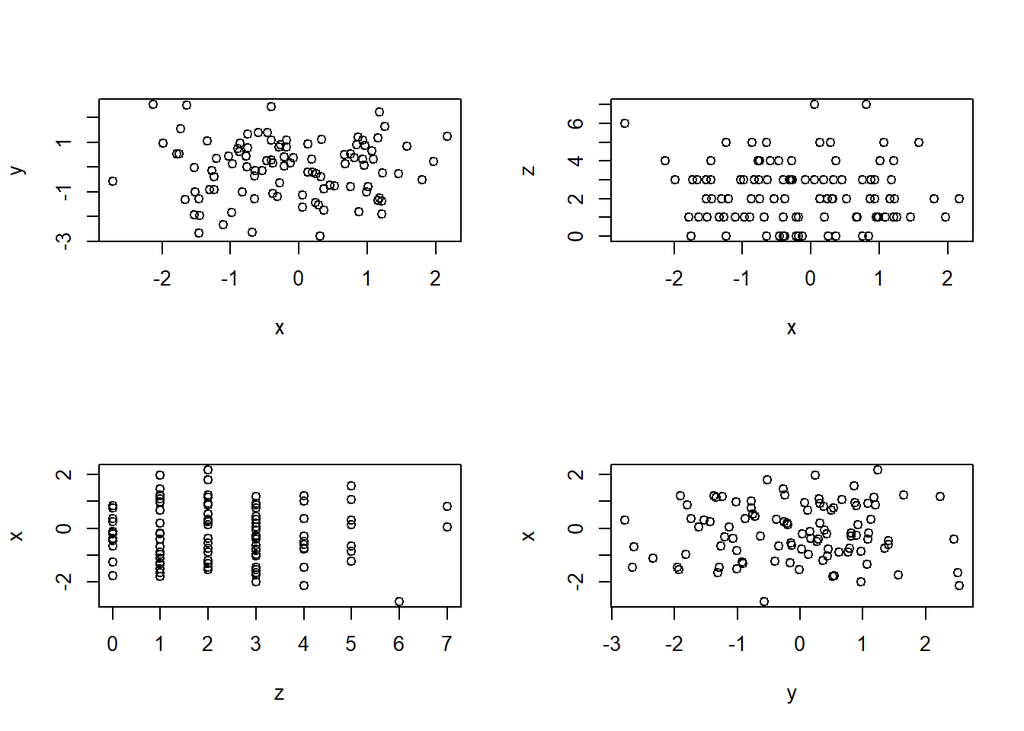

```r
par(mfrow = c(2, 2))
plot(x, y)
plot(x, z)
plot(z, x)
plot(y, x)
```

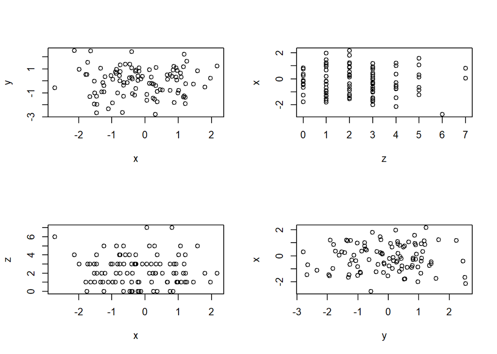

```r
par(mfcol = c(2, 2))
plot(x, y)
plot(x, z)
plot(z, x)
plot(y, x)
```

Lastly let’s look at how you can annotate data points.

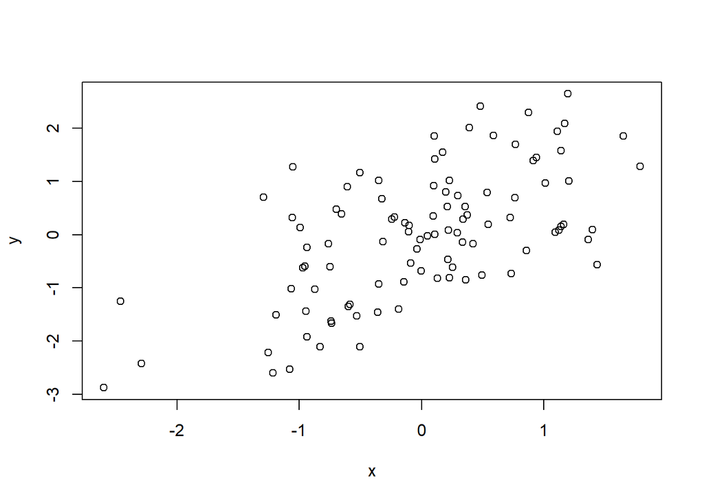

```r
par(mfrow = c(1, 1))
x <- rnorm(100) # some synthetic data
y <- x + rnorm(100) #some more synthetic data
g <- gl(2, 50, labels = c("Male", "Female")) # a factor variable with two levels
plot(x, y)
```

As it stands we can’t really tell which data points are the males and which data points are the females.

So we are going to build an empty plot and add the various elements one at a time.

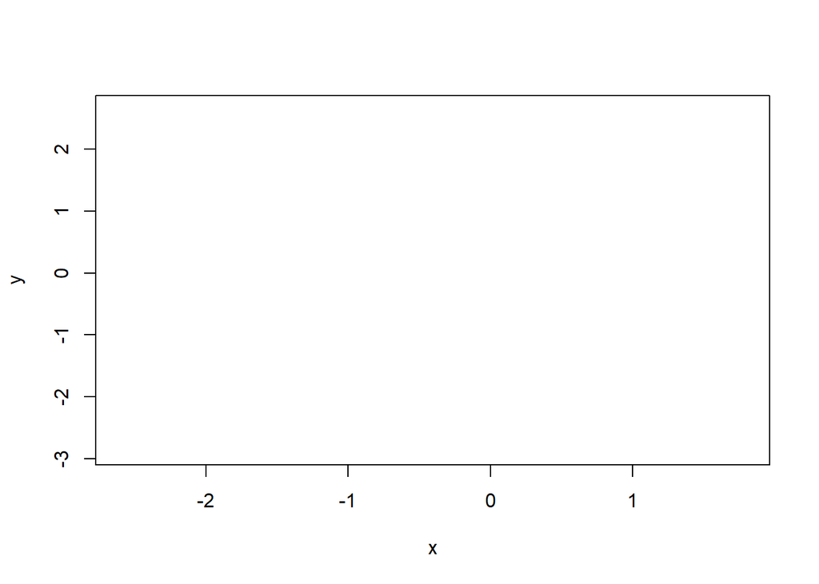

```r
plot(x, y, type = "n")
```

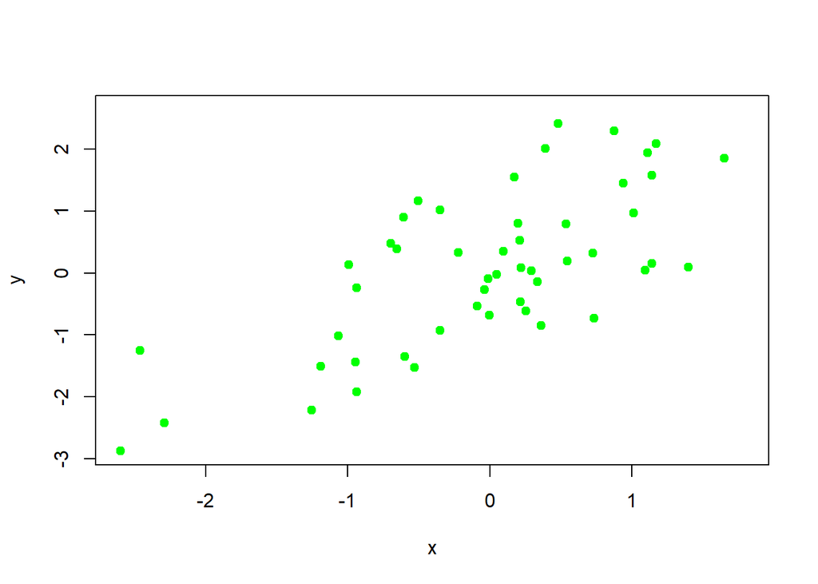

```r
plot(x, y, type = "n")
points(x[g == "Male"], y[g == "Male"], col = "green", pch = 19)
```

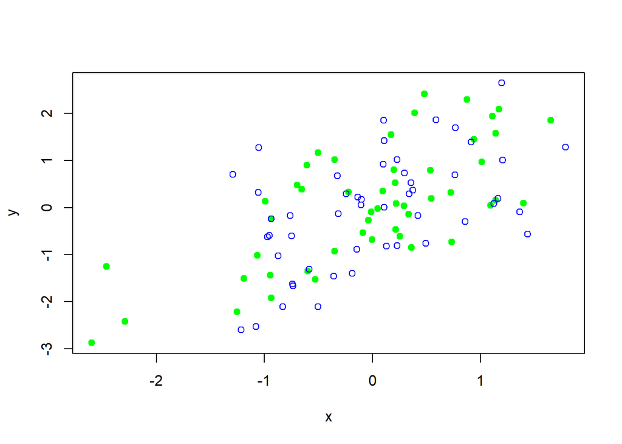

```r
plot(x, y, type = "n")
points(x[g == "Male"], y[g == "Male"], col = "green", pch = 19)
points(x[g == "Female"], y[g == "Female"], col = "blue")
```